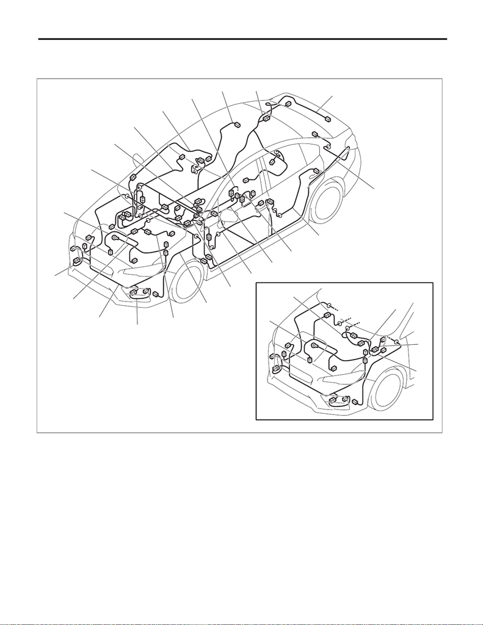

Harness Components Location

WIRING SYSTEM

60.Harness Components Location

A: LOCATION

(1) Front wiring harness (9) Roof cord (17) Bumper light cord RH

(2) Engine wiring harness (10) Trunk lid cord (18) Bumper light cord LH

ness

(4) Instrument panel wiring harness (12) Front door cord LH (20) Adapter cord RH

(5) Front door cord RH (13) Transmission cord (21) Adapter cord LH

(6) Rear door cord RH (14) Rear oxygen sensor cord (22) AUX adapter cord

(7) Rear wiring harness RH (15) Generator cord (23) Keyless access interior antenna

adapter cord

(8) Rear wiring harness LH (16) Center differential wiring harness

ENGINE TYPE EJ

(15)

(1)

(8)

(2)

(2)

(3)

(4)

(19)

(5)

(6)

(9)

(20)

(10)

(7)

(17)

(13)

(16)

(14)

(18)

(3)

(11)

(21)

(22)

(12)

(23)

(13)